# TokyoR 64 LT Rからmidiファイルを読んで plotしてみたお話

niszet

2017/08/26

# 自己紹介

# こんな人です

名前：niszet  
R歴：約１年  
趣味：R、楽器(お休み中)、ラズパイ

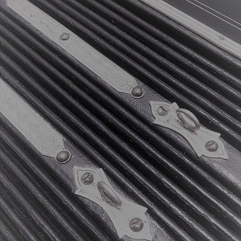

普段は回路設計などをして生きてます

# raw型とは…

# Rのデータ型(mode)いろいろ

- `integer`
- `numeric`
- `logical`
- `factor`
- `character`
- `raw` (今回紹介)
- `complex` (機会があれば)

# raw型=バイト型

- 1つの要素で `1byte = 8bit = 2**8 = 0-255` までを表すことが出来る
- バイナリファイル（データ）を扱う場合に使用する
- `complex`と共に大体のRの書籍では紹介されない影の存在
- `as.raw()` で0-255の整数を与えると作れる

# `raw`はRの`mode`の中でも最弱…

```r
c("a", as.raw(1)); c(1.0+1.0i, as.raw(1));
```

```
## [1] "a"  "01"
```

```
## [1] 1+1i 1+0i
```

```r
c(1.0, as.raw(1)); c(TRUE, as.raw(1));
```

```
## [1] 1 1
```

```
## [1] TRUE TRUE
```

- NULLなら勝てそう(NAはlogicalなので負ける)

# `operator`はほとんど使えない

- 加減乗除は使用できない

```r
# as.raw(1)+as.raw(1)
## Error in as.raw(1) + as.raw(1) :
##    non-numeric argument to binary operator
```

- 比較はできる

```r
as.raw(1)<as.raw(2)
```

```
## [1] TRUE
```

# bit単位のand, or演算が出来る

raw型に対しては`&` や`|`はbit単位でのAnd/Orをとる演算子となる。

```r
# 0011_1100(0x3c) & 0110_0110(0x66) = 0010_0100(0x24)
as.raw(60) & as.raw(102)
```

```
## [1] 24
```

```r
# 0011_1100(0x3c) & 0110_0110(0x66) = 0111_1110(0x7e)
as.raw(60) | as.raw(102)
```

```
## [1] 7e
```

ベクトル化も可能

```r
c(as.raw(12),as.raw(255)) & c(as.raw(255),as.raw(1))
```

```
## [1] 0c 01
```

# 関連する関数

- ファイルから(正確には`connection`から)値を読む
  - `readBin`
    - `readChar`(`ascii`の場合)
  - `scan`
- ファイルに値を書く
  - `writeBin`
    - `writeChar`(`ascii`の場合)

大体の場合は`as.raw()`と`as.integer()`で相互に型を変換して使うことになるかと思います 使い方はヘルプを参照ください(一番詳しい資料はヘルプ)

# midiファイルを読んでみる

# ライブラリを自作してみる

- `tuneR`パッケージにも`tuneR::readMidi`がありますが、欲しいものとちょっと違う…
  - waveファイルの読み込みなら`tuneR::readWave`でOK
- スタンダードMIDIファイルの仕様から頑張って実装…  
  “Standard MIDI Files (”SMF“) - The MIDI Association”

# 読んでみる

```r
# rsmf型として一旦ファイルを読む
smf <- read_smf("midi/AveMaria.mid")
# rsmf型から音の高さやなる時間などを抜き出してdata.frameに変換。
nf <- make_note_frame(smf)
# データの中身
head(nf, n=4)
```

```
##   ch height val start_time end_time nn
## 2  0     53  30          0       48  5
## 3  0     57  30         48       96  9
## 4  0     60  30         96      144  0
## 5  0     65  30        144      192  5
```

# read_smfの中身

```r
# read_smfの中身
head(read_smf)
```

```
##
## 1 function (file)
## 2 {
## 3     con <- file(file, "rb")
## 4     on.exit(close(con))
## 5     file_size <- file.info(file)[["size"]]
## 6     smf_header <- read_header(con)
```

```r
# その中でreadBinを使用しています
head(rmusicwork:::read_track_data_size)
```

```
##
## 1 function (con)
## 2 {
## 3     tds <- readBin(con, "integer", n = 1L, size = 4L, endian = "big")
## 4     tds
## 5 }
```

# plotしてみる

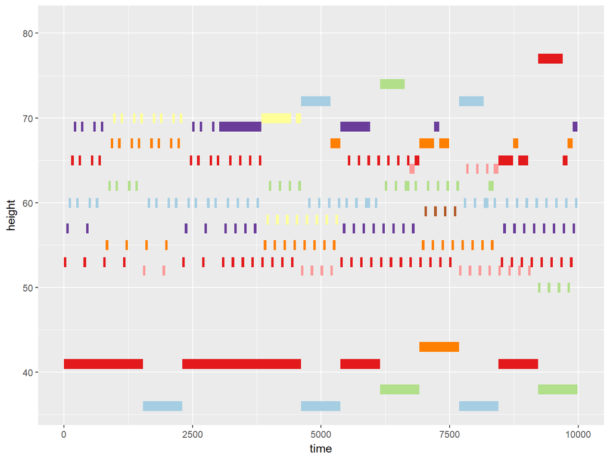

```r
# geom_segment で始点と終点になる列を指定。はじめの1/3だけplot
nf %>% ggplot()+geom_segment(aes(
  x=start_time, y=height, xend=end_time,yend=height,
  color=as.factor(nn), size=1)) + xlim(c(0,10000))+
  xlab("time") + ylab("height") + theme(legend.position="none")+
  scale_colour_brewer(palette = "Paired")
```

# まとめ

# まとめ

- やったこと
  - Rの関数だけでバイナリファイルを扱えることを確認した。
  - midiファイルを読むためのパッケージを作成しplot出来るようにした。
- 課題
  - ファイルの読み込みが遅い(可変長データのため。RCpp化する？)
  - data.frameからmidiファイルへ出力したい(SMFの理解が足りない)
    - 色々なデータセットから音を出せるようにしたい

# ありがとうぞうさん

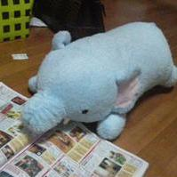

# Enjoy!!

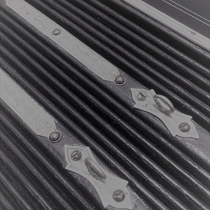